# Replicating Ellis-Soto et al 2023, Nat Hum Beh

Martin Bulla & Peter Mikula created by Martin Bulla

2025-08-26 16:07:14

# General note

For the sake of reproducibility we stored data and code provided by the authors with the paper in the folder ‘original_paper’ folder (at the root project’s directory) with subfolders ‘Data’ and ‘Code’, the latter two with the structure as provided by the authors. We stored the additional data acquired upon the request from The Institute for Replication at the ‘Data’ folder within the root project directory.

# Fig. 4

Code generating output that resembles Fig. 4 is located in two places, each yielding different results. (1) Code headed “6 trends” in the key analysis file `05_paper_1_analyses_R4_check.Rmd` generates trend lines for all four HOLC categories, but instead for sampling density supposedly depicted by Fig. 4, it depicts number of HOLC polygons that were sampled.

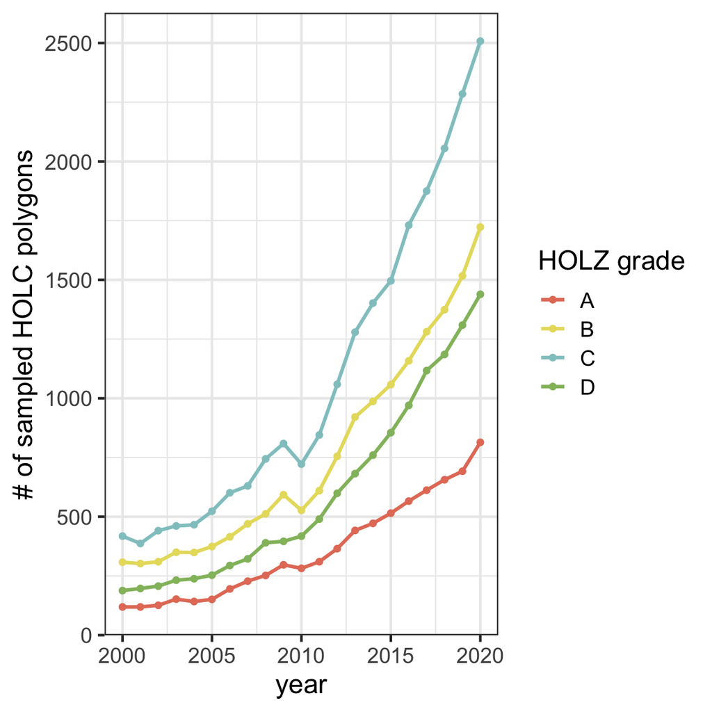

```r
# Here we show the authors original code with our adjustments indicate by MaPe

# Load packages
#suppressPackageStartupMessages(require(dplyr); require(ggplot2))
require(dplyr)
require(ggplot2)

# Color palette for redlining
holc_pal <- c('#92BC6B' # green
              , '#92C7C9' # blue
              , '#E7DC6B' # yellow
              , '#E47D67' # red
)#, '#A9A9A9' # dark gray)

suppressWarnings({ #MaPe added
  counts_grade_year <-
    readr::read_csv('original_paper/Data/Biodiv_Greeness_Social/R1_biodiv_trend_by_time_holc_id_1933_2022.csv',#MaPe changed folder path from read_csv('original_paper/Data/Biodiv_Greeness_Social/R1_biodiv_trend_by_time_holc_id_1933_2022.csv')
    show_col_types = FALSE   # MaPe added to suppress readr column spec message
    ) |>
    filter(holc_grade != 'E') |>
    arrange(year, holc_grade) |>
    group_by(year, holc_grade) |>
    count() |>
    group_by(year, holc_grade) |>
    summarise(cumsum = cumsum(n), .groups = "drop") # MaPe added ', .groups = "drop"' to suppress information messages
  })

# MaPe added color mapping
counts_grade_year |>
  filter(year >= 2000 & year <= 2020) |>
  ggplot(aes(year, cumsum, col = forcats::fct_rev(holc_grade))) +  #MaPe changed group (group=holc_grade) to col to label the holc_grade lines
  geom_point() + #MaPe added to aid visualisation
  geom_line(size = 1) +
  scale_color_manual(values = holc_pal, guide = guide_legend(reverse = TRUE), name = 'HOLZ grade') + #MaPe added for consistent coloring
  ylab('# of sampled HOLC polygons') + #MaPe added
  theme_bw(16) #MaPe added for consistency
```

```r
#ggsave('Output/Fig_r4_count.jpg', width= 15, height = 15, units ='cm')
```

2. Code in `` 04_R4_uneven_biodiversity_data_2023.R``, section [7] was not running due to absolute folder assignments that were unclear about where to actually locate the files. We searched for the files ``R1_biodiv_col_code_by_holc_id_2000_2020.csv`and`R1_biodiv_trend_by_time_holc_id_1933_2022.csv` among folders provided by the authors and respecified the folder paths. In addition, the original code loaded packages with conflicting functions. To smoothly reproduce the code, we thus made a new code (visible below) where we loaded only the relevant packages and only the relevant data. Then the script, thought to generate Fig. 4, run without issues. To aid visualisation we also plotted the points that the line was connecting and an alternative plot where the lines represent locally estimated scatterplot smoothing (LOESS).

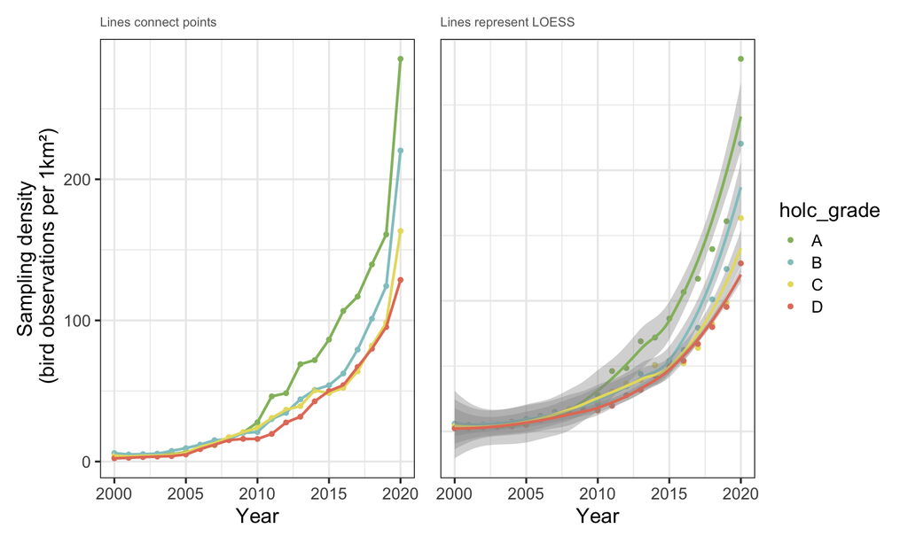

```r
# Here we show the authors original code with our adjustments indicate by MaPe

# Load packages
  require(dplyr)
  require(ggplot2)

# Color palette for redlining
holc_pal <- c('#92BC6B' # green
              , '#92C7C9' # blue
              , '#E7DC6B' # yellow
              , '#E47D67' # red
)#, '#A9A9A9' # dark gray)

# copy of the L51-65 of 04_R4_uneven_biodiversity_data_2023.R, with MaPe changed folder path
  holc <- sf::st_read('Data/holc_ad_data.shp') %>% #MaPe changed folder path
    sf::st_cast('POLYGON') %>% # IMPORTANT
    dplyr::filter(!sf::st_is_empty(.)) %>%
    sf::st_make_valid(.) %>%
    tibble::rowid_to_column() %>%
    dplyr::mutate(  id = paste(state, city, holc_id, holc_grade, rowid, sep = '_')
                    , city_state = paste0(city, ', ', state)
                    , area_holc_km2 = as.double(sf::st_area(.) / 1e+6)) %>%
    dplyr::select(id, state, city, holc_id, holc_grade, city_state, area_holc_km2)
  # Calculate the area of holc polygons
  holc_area <-  holc %>% dplyr::select(city, holc_grade, area_holc_km2) %>% dplyr::group_by(holc_grade) %>% dplyr::summarise(area_sum = sum(area_holc_km2)) %>% dplyr::filter(holc_grade != 'E')  %>% as_tibble() %>% dplyr::select(-geometry)
  # MaPe gives
    #  $ holc_grade: chr [1:4] "A" "B" "C" "D"
    #  $ area_sum  : num [1:4] 1282 2948 4365 2689

#copy of the L391-430 of 04_R4_uneven_biodiversity_data_2023.R, with changed folder path
# Load 1933-2022 data
temporal_trend = read.table('original_paper/Data/Biodiv_Greeness_Social/R1_biodiv_trend_by_time_holc_id_1933_2022.csv', header= T,sep=',')
# names(temporal_trend) <- c('Year','holc_grade','Type','holc_polygon_id', 'Sum')
names(temporal_trend) <- c('Year','holc_grade', 'Sum')
temporal_trend = temporal_trend %>% filter(holc_grade != 'E')
# MaPe hashtagged out as it needed other data, not relevant for the current case: sum(temporal_2000_2020$Sum,na.rm=T) / sum(temporal_trend$Sum,na.rm=T) # 77.8 % of biodiversity data collected in last 20 years !

temporal_all_data = plyr::ddply(temporal_trend, 'holc_grade', function(x){
  plyr::ddply(x, 'Year', function(z){
    data.frame(
      Year = unique(z$Year),
      holc_grade = unique(z$holc_grade),
      n_obs = sum(z$Sum,na.rm=T)
      #    n_obs_cum = cumsum(z$Sum)
    )

  })
})

tmpppp = temporal_all_data %>% group_by(holc_grade, Year) # %>% mutate(cumsum = cumsum(n_obs))

trend_A = tmpppp %>% filter(holc_grade == 'A') %>% mutate(cumsum_n_obs = cumsum(n_obs)) %>% left_join(holc_area) %>% mutate(sampling_density = cumsum_n_obs /area_sum )

trend_B  = tmpppp %>% filter(holc_grade == 'B') %>% mutate(cumsum_n_obs = cumsum(n_obs)) %>% left_join(holc_area) %>% mutate(sampling_density = cumsum_n_obs /area_sum )

trend_C  = tmpppp %>% filter(holc_grade == 'C') %>% mutate(cumsum_n_obs = cumsum(n_obs)) %>% left_join(holc_area) %>% mutate(sampling_density = cumsum_n_obs /area_sum )

trend_D  = tmpppp %>% filter(holc_grade == 'D') %>% mutate(cumsum_n_obs = cumsum(n_obs)) %>% left_join(holc_area) %>% mutate(sampling_density = cumsum_n_obs /area_sum )

temporal_all_data = rbind(trend_A,trend_B,trend_C,trend_D) # MaPe added 2 in the name to aid data investigation

# Plot temporal trend: 2000-2020; same as in the script, but showing legend
g1 =
temporal_all_data %>%
filter(Year >= 2000 & Year <= 2020) %>%
#filter(Year >= 2010 & Year <= 2019) %>%
#filter(Year <= 2020) %>%
ggplot(aes(x = Year, y = sampling_density), fill = holc_grade) +
geom_point(aes(color = holc_grade)) + # MaPe added to aid visualisation
geom_line(aes(color = holc_grade), size = 1, show.legend = FALSE) +
#stat_smooth(aes(color = holc_grade), size = 1) +
scale_color_manual(values = holc_pal) +
labs(subtitle = 'Lines connect points') + # MaPe added subtitle
theme_bw(16) +
#theme(legend.position = 'none') + # MaPe hashtagged out to aid visualisation
ylab('Sampling density\n (bird observations per 1km²)')+
  theme( plot.subtitle = element_text(size = 10, colour = "grey40"))

#g1; ggsave('Output/Fig_r4_density.jpg', width= 15, height = 15, units ='cm')

# MaPe - LOESS smoothed
g2 =
temporal_all_data %>%
filter(Year >= 2000 & Year <= 2020) %>%
#filter(Year >= 2010 & Year <= 2019) %>%
#filter(Year <= 2020) %>%
ggplot(aes(x = Year, y = sampling_density), fill = holc_grade) +
geom_point(aes(color = holc_grade)) + # MaPe added to aid visualisation
#geom_line(aes(color = holc_grade), size = 1) +
stat_smooth(aes(color = holc_grade), size = 1, show.legend = FALSE) +
scale_color_manual(values = holc_pal) +
labs(subtitle = 'Lines represent LOESS') + # MaPe added subtitle
theme_bw(16) +
#theme(legend.position = 'none') + # MaPe hashtagged out to aid visualisation
ylab('Sampling density\n (bird observations per 1km²)')+
theme( plot.subtitle = element_text(size = 10, colour = "grey40"))
#g2; ggsave('Output/Fig_r4_density_LOESS.jpg', width= 15, height = 15, units ='cm')

# MaPe: combine the above plots
library(patchwork)
g2_ <- g2 + theme(axis.title.y = element_blank(),
                axis.text.y  = element_blank(),
                axis.ticks.y = element_blank())

(g1 + g2_) +
plot_layout(guides = "collect") & # collect legends to one
theme(legend.position = "right")  # place legend on right
```

```r
#ggsave('Output/Fig_r4_density_ab.jpg', width= 25, height = 15, units ='cm')
```

The generated plots show sampling density per km2, which differs from the supposed sampling density per km2 depicted in the main text Fig. 4 (copied below).

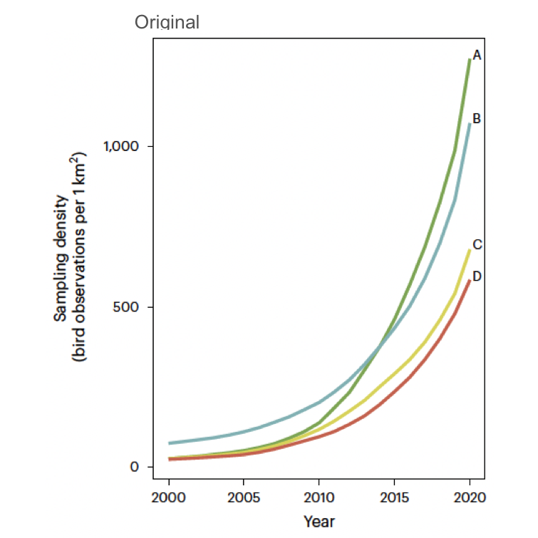

```r
library(png)       # or jpeg
library(grid)
library(cowplot)

# image panel
img_panel <- ggdraw() + draw_image("original_paper/ori_Fig_4.png")

# title as its own row
img_title <- ggdraw() +
  draw_label("Original",
             x = 0.25, hjust = 0, vjust = 1, size = 10, color='grey40') +
  theme(plot.margin = margin(0, 0, 0, 0))

# combine title + image
plot_grid(img_title, img_panel, ncol = 1,
                            rel_heights = c(0.06, 1))
```

The corrected figure, we have generated shows that (i) sampling for all categories was similar until ±2009, and (ii) the differences in sampling between categories likely increase. Note however, that such differences are easier to see if we plot the sampling densities of two categories agains each other.

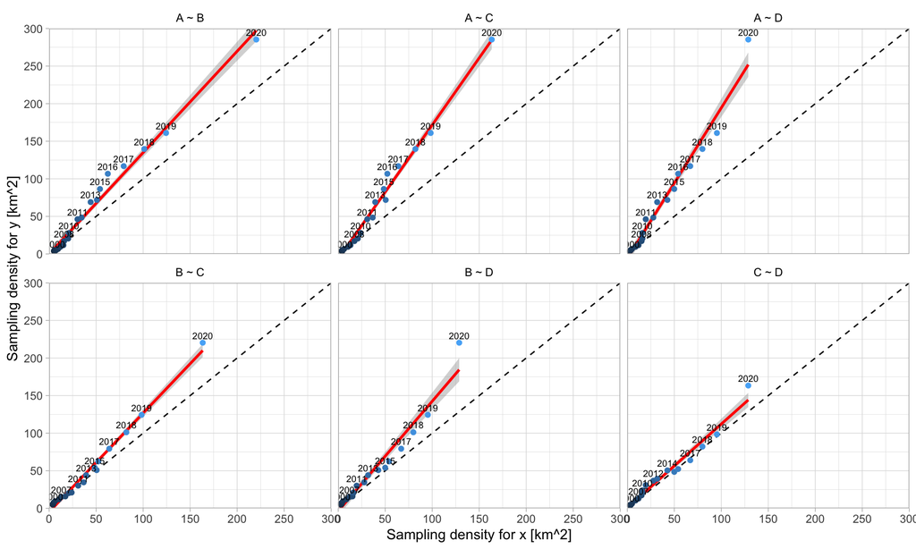

```r
require(data.table)

# replicate data manipulatin  with data.table
tt = fread('original_paper/Data/Biodiv_Greeness_Social/R1_biodiv_trend_by_time_holc_id_1933_2022.csv')
#tt = fread('Data/from_script_04/R1_biodiv_trend_by_time_holc_id_1933_2022.csv')
# names(temporal_trend) <- c('Year','holc_grade','Type','holc_polygon_id', 'Sum')
names(tt) <- c('Year','holc_grade', 'Sum')

tt = tt[holc_grade != 'E'] #d = data.table(temporal_trend)
d = tt[, .(n_obs = sum(Sum)), by = list(Year, holc_grade)]
d = d[order(holc_grade,Year)]

# add holc grade
holc_area_dt = data.table(holc_area)
dh = merge(d,holc_area_dt, all.x = TRUE)
dh[, sampling_density := n_obs/area_sum]
dd = dh[Year >= 2000 & Year <= 2020]
#filter(Year >= 2010 & Year <= 2019) %>%
#filter(Year <= 2020) %>%

# all pairwise combinations you want
library(ggrepel)

pairs <- data.table(
  x = c("D","D","D","C","C","B"),
  y = c("A","B","C","A","B","A")
)

# join to create plotting dataset
plotdat <- pairs[, .(x, y)][
  , merge(dh[holc_grade==x], dh[holc_grade==y], by="Year", suffixes=c(".x",".y")),
  by=.(x,y)
][, pair := paste0(y, " ~ ", x)]

# plot
ggplot(plotdat[Year >= 2000 & Year <= 2020], aes(sampling_density.x, sampling_density.y)) +
  geom_abline(slope=1, intercept=0, linetype="dashed", color="black") +
  geom_smooth(method="lm", col = 'red') +
  geom_point(aes(col=Year), show.legend = FALSE) +
  geom_text(aes(label=Year), vjust=-0.6, size=2.5, check_overlap=TRUE) +
  scale_x_continuous(breaks=seq(0,300,50), expand = c(0,0)) +
  scale_y_continuous(breaks=seq(0,300,50), expand = c(0,0)) +
  coord_cartesian(xlim=c(0,300), ylim=c(0,300)) +
  facet_wrap(~pair, scales="fixed") +
  labs(x="Sampling density for x [km^2]", y="Sampling density for y [km^2]")+
  theme_light()+
  theme(
    strip.background = element_blank(),       # remove grey panel background
    strip.text = element_text(color = "black") # make labels black
  )
```

```r
# ggsave('Output/Fig_r4_alternative.jpg', width= 21, height = 14, units ='cm')
```

Such figure clearly shows the described effects. However, same as the intended Fig. 4, the data are heavily psedoreplicated because they do not account for spatial and temporal auto-correlation.